# {introverse} quick docs

Custom scales in `ggplot2`  
**`get_help()` docs**

### Description

All functions documented here are part of the [`{ggplot2}`](https://ggplot2.tidyverse.org/) package, which is part of the [`{tidyverse}`](https://www.tidyverse.org/).

The `{ggplot2}` package [provides several useful functions](https://ggplot2.tidyverse.org/reference/scale_manual.html) (and see [here](https://ggplot2.tidyverse.org/reference/scale_gradient.html)) for creating your own aesthetic mapping scales. With these functions, you can manually customize how colors, fills, shapes, sizes, alpha (transparency), and and linetypes are mapped to your data. *You should only use these functions when you have MAPPED an aesthetic.* If you are trying to specify a color, fill, shape, etc. directly without any mapping, simply provide the argument to the geom of interest.

All functions are named `scale_AESTHETIC-TYPE_manual()` (except for those ending in `gradient()` or `gradient2()`, which are used for continuous mappings), where `AESTHETIC-TYPE` is a type of aesthetic mapping you have specified. These functions include:

| Function | Specify custom mapping of… |
| --- | --- |
| `scale_color_manual()` (aka `scale_colour_manual()`) | Discrete/categorical colors |
| `scale_fill_manual()` | Discrete/categorical fills |
| `scale_color_gradient()` (aka `scale_colour_gradient()`) | Continuous gradient colors |
| `scale_color_gradient2()` (aka `scale_colour_gradient2()`) | Continuous gradient2 colors |
| `scale_fill_gradient()` | Continuous gradient fills |
| `scale_fill_gradient2()` | Continuous gradient2 fills |
| `scale_shape_manual()` | Shapes |
| `scale_alpha_manual()` | Alpha (transparency) level |
| `scale_size_manual()` | Sizes (This is generally *not recommended* unless you really know what you’re doing, since it is easy to distort sizes and make interpretation difficult) |
| `scale_linetype_manual()` | Linetypes |

For more information about *color and fill scales specifically*, either…

- [See this tutorial on the `{introverse}` website](https://sjspielman.github.io/introverse/articles/color_fill_scales.html)
- Or, run this command in `R` Console: `vignette("color_fill_scales", package = "introverse")`

To use these functions, you need to either first load the `{ggplot2}` library, or always use the function with `ggplot2::()` notation.

```r
# Load the library
library(ggplot2)
# Or, load the full tidyverse:
library(tidyverse)

# Or, use :: notation, for example with scale_color_manual()
ggplot2::scale_color_manual()
```

### Conceptual Usage

```r
# Basic usage of non-gradient functions:
scale_AESTHETIC-TYPE_manual(values = c(array, of, values, to, use, for, mapping))

scale_AESTHETIC-TYPE_manual(values = c(array, of, values, to, use, for, mapping),
                            na.value = specify value to use for data mapping to NA)

# Note that the legend name can be specified here or with `ggplot2::labs()`
scale_AESTHETIC-TYPE_manual(name = Name of legend associated with this mapping,
                            values = c(array, of, values, to, use, for, mapping))

# Basic usage of color/fill gradient functions:
scale_AESTHETIC-TYPE_gradient(low = 'low color', high = 'high color')
scale_AESTHETIC-TYPE_gradient2(low = 'low color',
                               high = 'high color',
                               mid = 'midpoint color',
                               midpoint = 'midpoint value where gradient switches')
```

### Examples

The examples below use the `msleep` dataset. Learn more about this dataset with `get_help("msleep")`.

```r
# Show the msleep dataset with head()
head(msleep)
```

[output not shown]

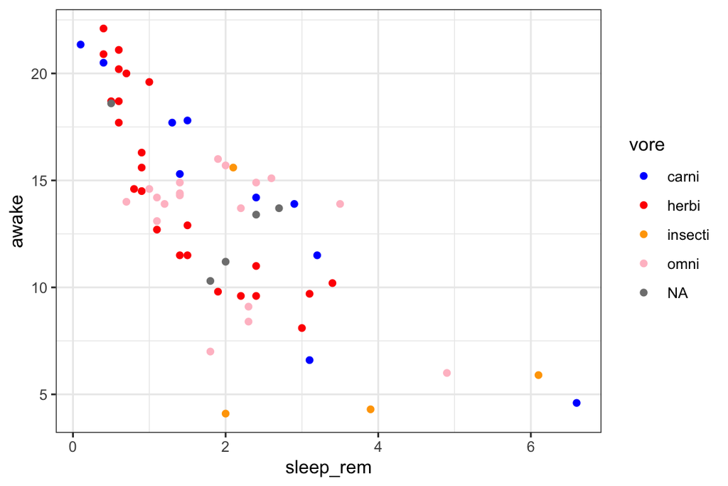

```r
# Specify custom colors for the `vore` color mapping, ensuring the number of values MATCHES the number of vores (except NAs)
ggplot(msleep) +
  aes(x = sleep_rem,
      y = awake,
      color = vore) +
  geom_point() +
  scale_color_manual(
    # There are 4 vores, so we need 4 colors
    values = c("blue", "red", "orange", "pink")
  )
```

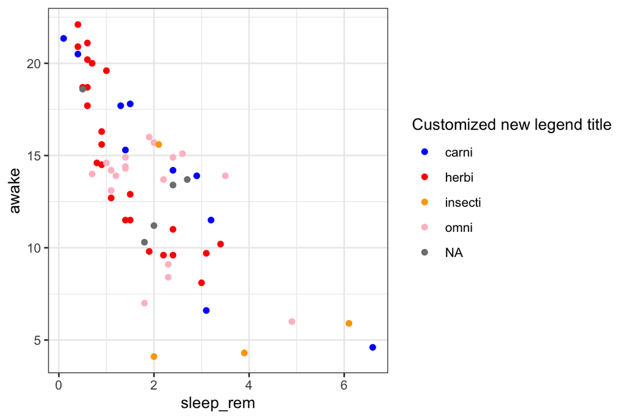

```r
# Specify custom colors for the `vore` color mapping, ensuring the number of values MATCHES the number of vores (except NAs)
# This time, use the `name` argument for a customized legend title
ggplot(msleep) +
  aes(x = sleep_rem,
      y = awake,
      color = vore) +
  geom_point() +
  scale_color_manual(
    name = "Customized new legend title",
    # There are 4 vores, so we need 4 colors
    values = c("blue", "red", "orange", "pink")
  )
```

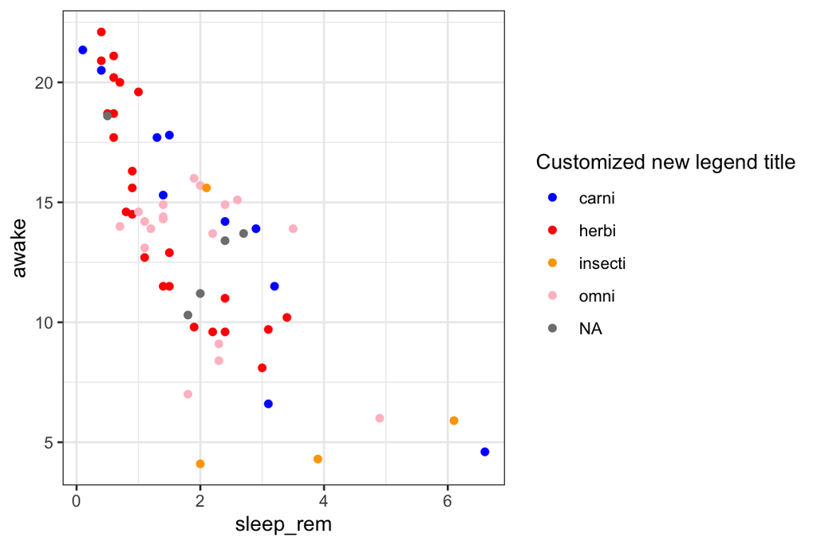

```r
# Instead of the previous example, you can also `labs()` to specify the legend title
ggplot(msleep) +
  aes(x = sleep_rem,
      y = awake,
      color = vore) +
  geom_point() +
  scale_color_manual( values = c("blue", "red", "orange", "pink")) +
  labs(color = "Customized new legend title")
```

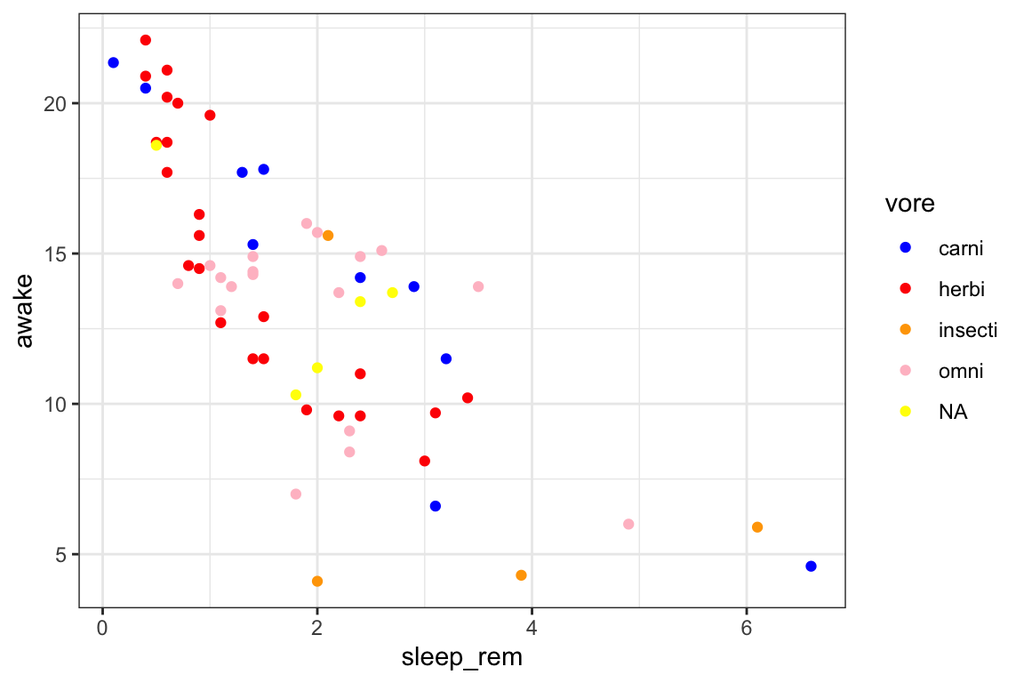

```r
# To customize the color used for NA values, use the argument `na.value`
ggplot(msleep) +
  aes(x = sleep_rem,
      y = awake,
      color = vore) +
  geom_point() +
  scale_color_manual(
    values = c("blue", "red", "orange", "pink"),
    na.value = "yellow" # Now all vore that are NA will be yellow instead of the default dark gray
  )
```

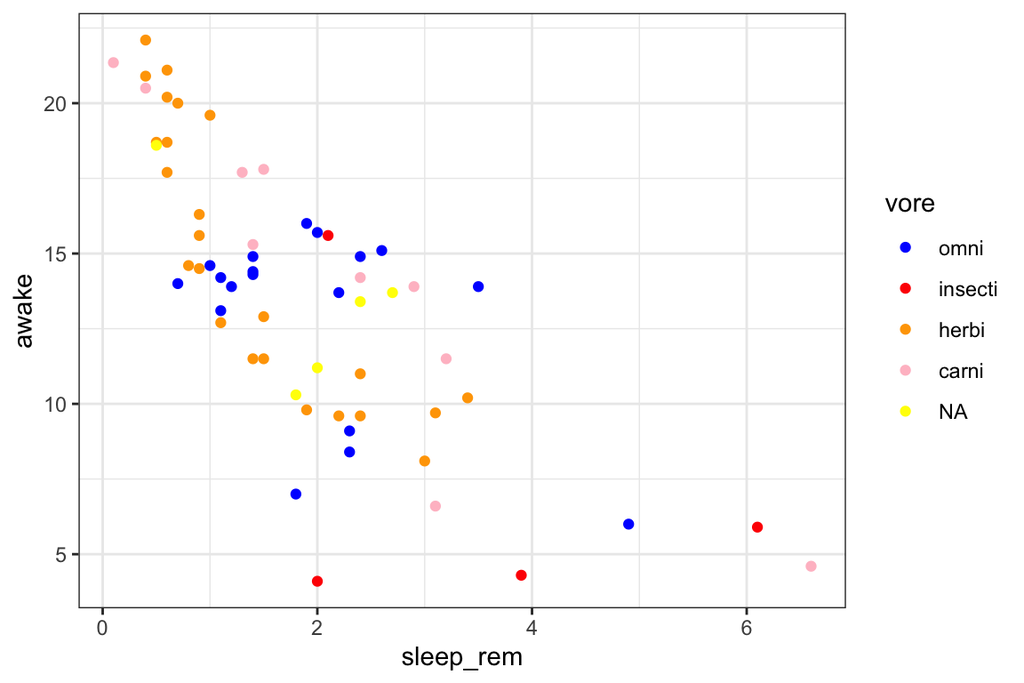

```r
# The values are applied in the order values appear on the axis
# If you change the order with forcats, colors get applied in the new order
# Again, when using forcats, it's best practice to clean up the legend title
ggplot(msleep) +
  aes(x = sleep_rem,
      y = awake,
      # For example, reverse the order of vore in the plot
      color = forcats::fct_rev(vore)) +
  geom_point() +
  scale_color_manual(
    name = "vore", # Adding legend title to clean up after forcats usage
    values = c("blue", "red", "orange", "pink"),
    na.value = "yellow" # Now all vore that are NA will be yellow instead of the default dark gray
  )
```

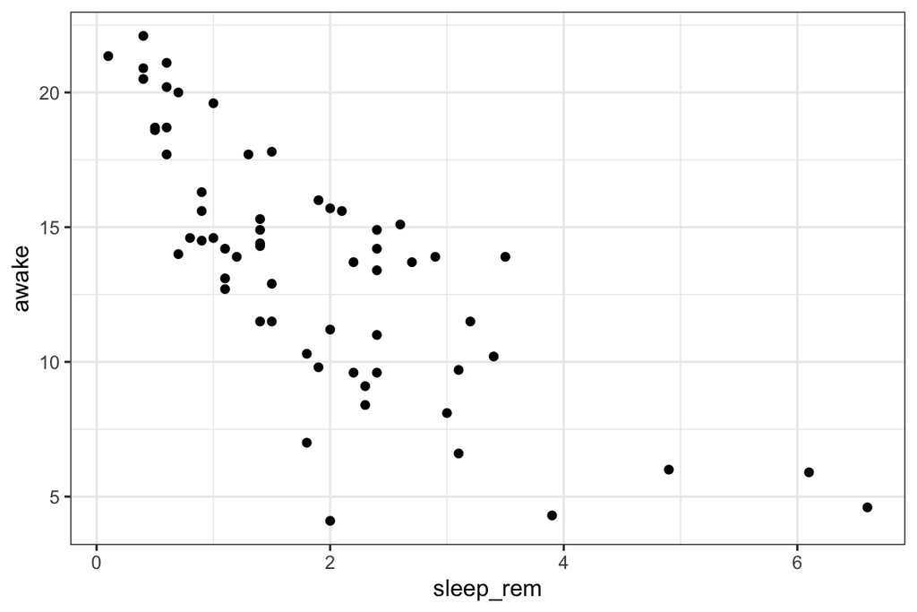

```r
# CAUTION!! If you don't include an aesthetic in the first place, none of your manual values appear
ggplot(msleep) +
  aes(x = sleep_rem,
      y = awake) + # forgetting the color = vore means no colors and no legend show up
  geom_point() +
  scale_color_manual(values = c("blue", "red", "orange", "pink"))
```

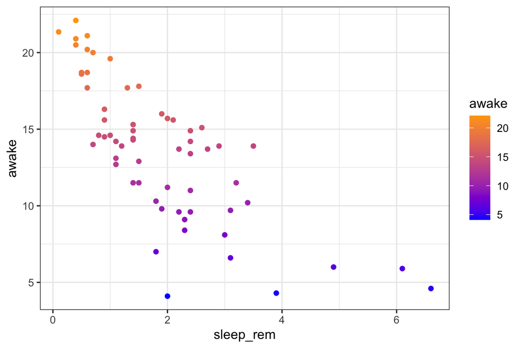

```r
# Use a custom gradient mapping, suitable since we are now coloring by `awake`, a continuous variable
ggplot(msleep) +
  aes(x = sleep_rem,
      y = awake,
      color = awake) +  # Color by continuous variable awake
  geom_point() +
  scale_color_gradient(
    low = "blue",
    high = "orange"
  )
```